THELANCET-D-15-02346

Open access raw data, tidy data, code book and statistical inference for the journal article:

# Living longer with disability in China and G20 nations: a quantitative model for the Sustainable Development Goal for health post-2015. A reproducible research

## Accepted at the Lancet-Chinese Academy of Medical Sciences (CAMS) Health Summit, Beijing, China, Oct 30–31, 2015

### Dr Stefano Olgiati, PhD, MS (1), Prof. Alessandro Danovi, MS (2)

1. Author Responsible For Correspondence: University of Bergamo , Department of Quantitative Methods, via dei Caniana 2, Bergamo (ITA) 24129; tel +39 035 20 52 638; fax +39 035 20 52 549; email stefano.olgiati@unibg.it
2. University of Bergamo, Faculty of Economics, Bergamo (ITA) 24129

**NOTICE TO FELLOW RESEARCHERS:**_ *1) THE WHO AS OF JULY 18, 2015, HAS UPDATED SOME DATABASES UTILIZED AS RAW DATA FOR THE TIDY DATASETS AND THE STATISTICAL INFERENCE. ACCORDINGLY, AFTER RUNNING THE PRESENT PROGRAM SOME OF THE NUMERIC FINDINGS MAY SLIGHTLY DIFFER FROM THE FINDINGS REPORTED IN THE JOURNAL ARTICLE THELANCET-D-15-02346 (DOI not yet released). THE AUTHORS HAVE CHOSEN NOT TO “FREEZE” THE ORIGINAL DATA SOURCE BUT TO ALLOW AUTOMATIC UPDATING OF THE RESEARCH FINDINGS IN THE HTML DOCUMENT. THIS CAN BE VERIFIED BY THE > dateDownloaded CODE IN R AND TRACED BY SUBSEQUENT UPDATES IN THE OA GITHUB REPOSITORY. THIS IS A FURTHER ADVANTAGE IN TERMS OF TRANSPARENCY OF RESEARCH REPRODUCIBILITY;*

**2)AS OF OCTOBER 2, 2015 THE UNIVERSITY OF WASHINGTON GBDx HAS PERMANENTLY MOVED THE URL. THE DOWNLOAD CODE HAS BEEN UPDATED AND THE MESSAGE FROM THE OLD URL UPLOADED IN GITHUB FOR TRANSPARENCY AND EVIDENCE**

**3)AS OF OCTOBER 2, 2015 SOFTWARE UPDATE TO MAC OS X EL CAPITAN 10.11 HAS REQUIRED TO ADD THE METHOD “curl” TO download.file function in R**

**THANK YOU. THE AUTHORS**

### Raw Data

We utilized open access data from:

1. the Institute for Health Metrics and Evaluation (IHME) Global Burden of Disease Study 2010 GHDx;
2. the World Health Organization’s Data Repository on Health Expenditure.

### Code Book

The following variables and definitions, based on “The Global Burden of Disease: Generating Evidence, Guiding Policy” and the World Health Organization’s Data Repository on Health Expenditure, were adopted when extracting the tidy data set from the raw data:

- Life Expectancy at birth: Life Expectancy at birth is the average number of years that a person can be expected to live from age 0-1;
- Health Adjusted Life Expectancy (HALE) at birth: Healthy Life Expectancy at birth is the average number of years that a person can be expected to live in “full health” from age 0-1, by taking into account years lived in less than full health with disease and/or non-fatal injury ;
- Years Lived with Disability (YLD): The Years Lived with Disability is the difference between LE and HALE, where LE is always greater than or equal to HALE. It is equivalent to the number of years that people live with a health condition or its consequences or in less than full health with disease and/or non-fatal injury;
- Total Health Expenditure (THE): WHS7_105 Per capita total expenditure on health (PPP int.$) includes public (government, external resources for health from international programs and social security) and private expenditure (private pre-paid plans and out-of-pocket). For the purpose of international comparisons, THE is expressed in International Purchase Power Parity United States Dollars (USD PPP) which, according to the World Bank, is the number of units of a country’s currency required to buy the same amounts of goods and services in the domestic market as one US Dollar would buy in the United States.

### Raw Data

Downloading data from the repositories

```r
# Getting raw data from the IHME Global Burden of Disease Study 2010
fileURL.GBD <- "http://ghdx.healthdata.org/sites/default/files/record-attached-files/IHME_GBD_2010_HALE_BY_COUNTRY_1990_2010_Y2010M02D23.CSV"

# Getting raw data from the WHO Health Expenditure Repository
fileURL.WHO <- "http://apps.who.int/gho/athena/data/xmart.csv?target=GHO/WHS7_156,WHS7_105,WHS7_104,WHS7_108&profile=xmart&filter=COUNTRY:*;REGION:AFR;REGION:AMR;REGION:SEAR;REGION:EUR;REGION:EMR;REGION:WPR"

download.file(fileURL.GBD, destfile="GBD.csv", method="curl")
download.file(fileURL.WHO, destfile="WHO.csv", method="curl")

dateDownloaded <- date()
dateDownloaded
```

```
## [1] "Sun Oct  4 14:29:59 2015"
```

Reading raw data in .csv format

```r
# Raw Data
raw.data.GBD <- read.csv("GBD.csv")
raw.data.WHO <- read.csv("WHO.csv")
names(raw.data.GBD)
```

```
## [1] "iso3"         "country_name" "year"         "age_name"
## [5] "sex_name"     "le"           "le_ui"        "hale"
## [9] "hale_ui"
```

```r
names(raw.data.WHO)
```

```
##  [1] "Dataset"      "GHO"          "DATASOURCE"   "PUBLISHSTATE"
##  [5] "YEAR"         "REGION"       "COUNTRY"      "Display"
##  [9] "Numeric"      "Low"          "High"         "Comments"
```

```r
dim(raw.data.GBD)
```

```
## [1] 50490     9
```

```r
dim(raw.data.WHO)
```

```
## [1] 14399    12
```

```r
# Data Tables
attach(raw.data.GBD)
attach(raw.data.WHO)

DT.GBD <- data.table(raw.data.GBD)
DT.WHO <- data.table(raw.data.WHO)

tables()
```

```
##      NAME     NROW NCOL MB
## [1,] DT.GBD 50,490    9  4
## [2,] DT.WHO 14,399   12  1
##      COLS
## [1,] iso3,country_name,year,age_name,sex_name,le,le_ui,hale,hale_ui
## [2,] Dataset,GHO,DATASOURCE,PUBLISHSTATE,YEAR,REGION,COUNTRY,Display,Numeric,Low,High
##      KEY
## [1,]
## [2,]
## Total: 5MB
```

### Tidy Data Set

Manipulating data to generate tidy datasets

```r
# ISO3 codes of G20 Countries for 1990/95 - 2010
# Argentina, Australia, Brazil, Canada, China, India, Indonesia, Japan, Mexico, Russia, Saudi Arabia, South Africa, South Korea, Turkey, the United Kingdom and the United States, European Union (EU)

ISO3 <- c("ARG", "AUS", "BRA", "CAN","CHN","IND","IDN","JPN","MEX","RUS","SAU","ZAF","KOR","TUR","USA", "AUT","BEL","BGR","HRV","CYP","CZE","DNK","EST","FIN","FRA","DEU","GRC","HUN","IRL","ITA","LVA","LTU","LUX","MLT","NLD","POL","PRT","ROU","SVK","SVN","ESP","SWE","GBR")

length(ISO3)
```

```
## [1] 43
```

```r
data.GBD.1990 <- DT.GBD[DT.GBD$year == "1990" & DT.GBD$age_name == "0-1 years" & DT.GBD$sex_name == "Both" & DT.GBD$iso3 %in% ISO3 , ]
data.GBD.1990.ordered <- data.GBD.1990[order(iso3), ]
data.GBD.1990.ordered
```

```
##     iso3   country_name year  age_name sex_name     le              le_ui
##  1:  ARG      Argentina 1990 0-1 years     Both 72.543 (72.481\x9672.601)
##  2:  AUS      Australia 1990 0-1 years     Both 76.869 (76.799\x9676.937)
##  3:  AUT        Austria 1990 0-1 years     Both 75.708 (75.609\x9675.816)
##  4:  BEL        Belgium 1990 0-1 years     Both 75.916 (75.822\x9676.016)
##  5:  BGR       Bulgaria 1990 0-1 years     Both 71.386 (71.285\x9671.485)
##  6:  BRA         Brazil 1990 0-1 years     Both 69.108 (68.920\x9669.271)
##  7:  CAN         Canada 1990 0-1 years     Both 77.196 (77.135\x9677.266)
##  8:  CHN          China 1990 0-1 years     Both 69.272 (68.331\x9670.294)
##  9:  CYP         Cyprus 1990 0-1 years     Both 78.026 (77.718\x9678.345)
## 10:  CZE Czech Republic 1990 0-1 years     Both 71.602 (71.516\x9671.690)
## 11:  DEU        Germany 1990 0-1 years     Both 75.367 (75.329\x9675.404)
## 12:  DNK        Denmark 1990 0-1 years     Both 75.160 (75.038\x9675.283)
## 13:  ESP          Spain 1990 0-1 years     Both 76.914 (76.858\x9676.970)
## 14:  EST        Estonia 1990 0-1 years     Both 69.839 (69.536\x9670.120)
```

[output cut: 75 more lines]

```r
data.GBD.2010 <- DT.GBD[DT.GBD$year == "2010" & DT.GBD$age_name == "0-1 years" & DT.GBD$sex_name == "Both" & DT.GBD$iso3 %in% ISO3 , ]
data.GBD.2010.ordered <- data.GBD.2010[order(iso3), ]
data.GBD.2010.ordered
```

```
##     iso3   country_name year  age_name sex_name     le              le_ui
##  1:  ARG      Argentina 2010 0-1 years     Both 75.957 (75.893\x9676.024)
##  2:  AUS      Australia 2010 0-1 years     Both 81.501 (81.409\x9681.582)
##  3:  AUT        Austria 2010 0-1 years     Both 80.612 (80.472\x9680.741)
##  4:  BEL        Belgium 2010 0-1 years     Both 79.531 (79.310\x9679.784)
##  5:  BGR       Bulgaria 2010 0-1 years     Both 73.526 (73.392\x9673.653)
##  6:  BRA         Brazil 2010 0-1 years     Both 74.078 (73.850\x9674.284)
##  7:  CAN         Canada 2010 0-1 years     Both 80.634 (80.430\x9680.816)
##  8:  CHN          China 2010 0-1 years     Both 75.719 (74.913\x9676.542)
##  9:  CYP         Cyprus 2010 0-1 years     Both 80.226 (79.875\x9680.624)
## 10:  CZE Czech Republic 2010 0-1 years     Both 77.523 (77.412\x9677.641)
## 11:  DEU        Germany 2010 0-1 years     Both 80.232 (80.074\x9680.391)
## 12:  DNK        Denmark 2010 0-1 years     Both 78.911 (78.771\x9679.073)
## 13:  ESP          Spain 2010 0-1 years     Both 81.354 (81.163\x9681.526)
## 14:  EST        Estonia 2010 0-1 years     Both 75.890 (75.608\x9676.177)
```

[output cut: 75 more lines]

```r
data.WHO.1995 <- DT.WHO[DT.WHO$YEAR == "1995" & DT.WHO$GHO == "WHS7_105" & DT.WHO$Numeric != "NA" & DT.WHO$COUNTRY %in% ISO3,  ]
data.WHO.1995.ordered <- data.WHO.1995[order(COUNTRY), ]
data.WHO.1995.ordered
```

```
##     Dataset      GHO DATASOURCE PUBLISHSTATE YEAR REGION COUNTRY Display
##  1:    CYCU WHS7_105    NHA_ARG    PUBLISHED 1995    AMR     ARG     649
##  2:    CYCU WHS7_105    NHA_AUS    PUBLISHED 1995    WPR     AUS    1625
##  3:    CYCU WHS7_105               PUBLISHED 1995    EUR     AUT    2253
##  4:    CYCU WHS7_105               PUBLISHED 1995    EUR     BEL    1710
##  5:    CYCU WHS7_105               PUBLISHED 1995    EUR     BGR     290
##  6:    CYCU WHS7_105               PUBLISHED 1995    AMR     BRA     522
##  7:    CYCU WHS7_105               PUBLISHED 1995    AMR     CAN    2070
##  8:    CYCU WHS7_105               PUBLISHED 1995    WPR     CHN      61
##  9:    CYCU WHS7_105               PUBLISHED 1995    EUR     CYP     730
## 10:    CYCU WHS7_105               PUBLISHED 1995    EUR     CZE     896
## 11:    CYCU WHS7_105               PUBLISHED 1995    EUR     DEU    2276
## 12:    CYCU WHS7_105               PUBLISHED 1995    EUR     DNK    1872
## 13:    CYCU WHS7_105               PUBLISHED 1995    EUR     ESP    1190
## 14:    CYCU WHS7_105               PUBLISHED 1995    EUR     EST     396
```

[output cut: 75 more lines]

```r
data.WHO.2010 <- DT.WHO[DT.WHO$YEAR == "2010" & DT.WHO$GHO == "WHS7_105" & DT.WHO$Numeric != "NA" & DT.WHO$COUNTRY %in% ISO3,  ]
data.WHO.2010.ordered <- data.WHO.2010[order(COUNTRY), ]
data.WHO.1995.ordered
```

```
##     Dataset      GHO DATASOURCE PUBLISHSTATE YEAR REGION COUNTRY Display
##  1:    CYCU WHS7_105    NHA_ARG    PUBLISHED 1995    AMR     ARG     649
##  2:    CYCU WHS7_105    NHA_AUS    PUBLISHED 1995    WPR     AUS    1625
##  3:    CYCU WHS7_105               PUBLISHED 1995    EUR     AUT    2253
##  4:    CYCU WHS7_105               PUBLISHED 1995    EUR     BEL    1710
##  5:    CYCU WHS7_105               PUBLISHED 1995    EUR     BGR     290
##  6:    CYCU WHS7_105               PUBLISHED 1995    AMR     BRA     522
##  7:    CYCU WHS7_105               PUBLISHED 1995    AMR     CAN    2070
##  8:    CYCU WHS7_105               PUBLISHED 1995    WPR     CHN      61
##  9:    CYCU WHS7_105               PUBLISHED 1995    EUR     CYP     730
## 10:    CYCU WHS7_105               PUBLISHED 1995    EUR     CZE     896
## 11:    CYCU WHS7_105               PUBLISHED 1995    EUR     DEU    2276
## 12:    CYCU WHS7_105               PUBLISHED 1995    EUR     DNK    1872
## 13:    CYCU WHS7_105               PUBLISHED 1995    EUR     ESP    1190
## 14:    CYCU WHS7_105               PUBLISHED 1995    EUR     EST     396
```

[output cut: 75 more lines]

```r
data.1990 <- data.frame(country=data.GBD.1990.ordered$iso3, le=data.GBD.1990.ordered$le, hale=data.GBD.1990.ordered$hale, the=data.WHO.1995.ordered$Numeric)

data.2010 <- data.frame(country=data.GBD.2010.ordered$iso3, le=data.GBD.2010.ordered$le, le_ui = data.GBD.2010.ordered$le_ui, hale=data.GBD.2010.ordered$hale, hale_ui = data.GBD.2010.ordered$hale_ui, the=data.WHO.2010.ordered$Numeric)


# Years Lived with Disease in G20 Countries for 1990 - 2010
yld.1990 <- data.1990$le - data.1990$hale
yld.2010 <- data.2010$le - data.2010$hale

# Tidy Dataset
tidy.data <- data.frame(country=data.2010$country, the_1995=data.1990$the, the_2010=data.2010$the, le_1990=data.1990$le,  le_2010=data.2010$le, le_ui_2010=data.2010$le_ui, hale_ui_2010=data.2010$hale_ui, hale_1990 = data.1990$hale, hale_2010 = data.2010$hale, yld_1990=yld.1990, yld_2010=yld.2010)

attach(tidy.data)

# Saving Tidy Dataset to .csv file
write.csv(tidy.data, "YLDOutput.csv")
```

### Background

```r
ID <- "CHN"

# Data for background and rationale
tidy.data$le_2010[tidy.data$country == ID]
```

```
## [1] 75.719
```

```r
tidy.data$le_1990[tidy.data$country == ID]
```

```
## [1] 69.272
```

```r
median(tidy.data$le_2010)
```

```
## [1] 78.911
```

```r
mad(tidy.data$le_2010)
```

```
## [1] 3.621992
```

```r
tidy.data$yld_2010[tidy.data$country == ID]
```

```
## [1] 7.948
```

```r
tidy.data$yld_1990[tidy.data$country == ID]
```

```
## [1] 7.57
```

```r
median(tidy.data$yld_2010)
```

```
## [1] 10.51
```

```r
mad(tidy.data$yld_2010)
```

```
## [1] 1.144567
```

```r
mean(tidy.data$yld_2010)
```

```
## [1] 10.48093
```

```r
var(tidy.data$yld_2010)
```

```
## [1] 1.084231
```

```r
tidy.data$hale_2010[tidy.data$country == ID]
```

```
## [1] 67.771
```

```r
tidy.data$hale_1990[tidy.data$country == ID]
```

```
## [1] 61.702
```

```r
median(tidy.data$hale_2010)
```

```
## [1] 67.871
```

```r
mad(tidy.data$hale_2010)
```

```
## [1] 2.622719
```

### Exploratory Data Analysis

```r
# Strip Charts
par(mfrow=(c(1,2)))

strip.data.1 <- data.frame("YEAR 1990"=le_1990, "YEAR 2010"= le_2010)
stripchart(strip.data.1,
           vertical=TRUE,
           col=c("black", "skyblue"),
           cex=1.5,
           lty = "solid",
           lwd = 2,
           method="jitter",
           main="Life Expectancy",
           ylab="Number of Years")
abline(h=c(median(le_1990), median(le_2010)),col=c("black", "skyblue"),
           lty = "solid",
           lwd = 2)
points(c(tidy.data$le_1990[tidy.data$country == ID], tidy.data$le_2010[tidy.data$country == ID]), pch=22, col="red", cex = 2, lty = "solid", lwd = 2)
text(c(tidy.data$le_1990[tidy.data$country == ID], tidy.data$le_2010[tidy.data$country == ID]), labels=ID, cex= 1.5, pos=c(4,2))
summary(strip.data.1)
```

```
##    YEAR.1990       YEAR.2010
##  Min.   :58.30   Min.   :59.90
##  1st Qu.:70.38   1st Qu.:74.93
##  Median :74.01   Median :78.91
##  Mean   :72.92   Mean   :77.08
##  3rd Qu.:76.39   3rd Qu.:80.20
##  Max.   :79.10   Max.   :82.65
```

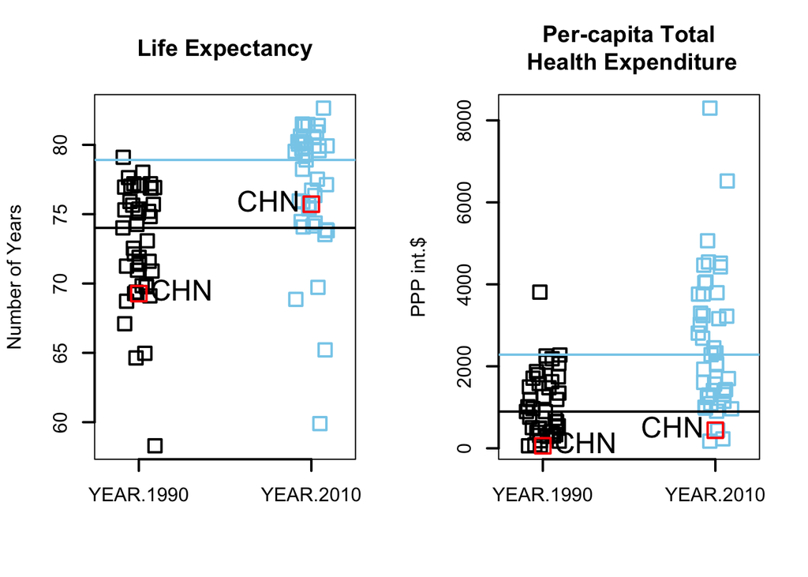

```r
strip.data.4 <- data.frame("YEAR 1990"=the_1995, "YEAR 2010"=the_2010)
stripchart(strip.data.4,
           vertical=TRUE,
           cex=1.5,
           lty = "solid",
           lwd = 2,
           col=c("black", "skyblue"),
           method="jitter",
           main="Per-capita Total\n Health Expenditure",
           ylab="PPP int.$")
abline(h=c(median(the_1995), median(the_2010)),col=c("black", "skyblue"),
           lty = "solid",
           lwd = 2)
points(c(tidy.data$the_1995[tidy.data$country == ID], tidy.data$the_2010[tidy.data$country == ID]), pch=22, col="red", cex = 2, lty = "solid", lwd = 2)
text(c(tidy.data$the_1995[tidy.data$country == ID], tidy.data$the_2010[tidy.data$country == ID]), labels=ID, cex= 1.5, pos=c(4,2))
```

```r
summary(strip.data.4)
```

```
##    YEAR.1990      YEAR.2010
##  Min.   :  61   Min.   : 174
##  1st Qu.: 401   1st Qu.:1306
##  Median : 896   Median :2284
##  Mean   :1049   Mean   :2597
##  3rd Qu.:1602   3rd Qu.:3762
##  Max.   :3810   Max.   :8299
```

```r
par(mfrow=(c(1,2)))

strip.data.2 <- data.frame("YEAR 1990"=hale_1990, "YEAR 2010"=hale_2010)
stripchart(strip.data.2,
           vertical=TRUE,
           col=c("black", "skyblue"),
           cex=1.5,
           lty = "solid",
           lwd = 2,
           method="jitter",
           main="Health-Adjusted \n Life Expectancy",
           ylab="Number of Years")
abline(h=c(median(hale_1990), median(hale_2010)),col=c("black", "skyblue"),
           lty = "solid",
           lwd = 2)
points(c(tidy.data$hale_1990[tidy.data$country == ID], tidy.data$hale_2010[tidy.data$country == ID]), pch=22, col="red", cex = 2, lty = "solid", lwd = 2)
text(c(tidy.data$hale_1990[tidy.data$country == ID], tidy.data$hale_2010[tidy.data$country == ID]), labels=ID, cex= 1.5, pos=c(4,2))
summary(strip.data.2)
```

```
##    YEAR.1990       YEAR.2010
##  Min.   :49.75   Min.   :50.98
##  1st Qu.:61.39   1st Qu.:64.71
##  Median :63.84   Median :67.87
##  Mean   :63.23   Mean   :66.60
##  3rd Qu.:66.10   3rd Qu.:68.94
##  Max.   :70.06   Max.   :73.10
```

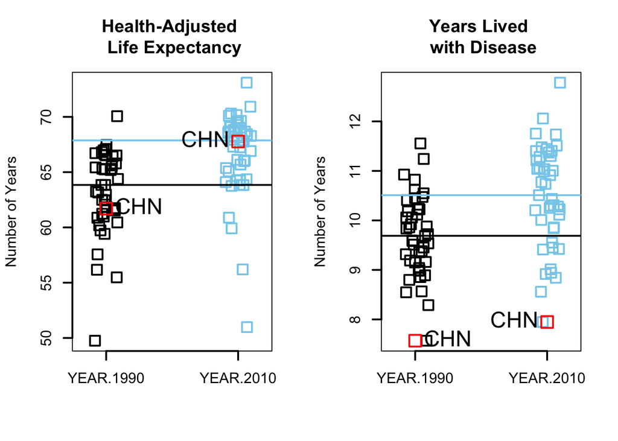

```r
strip.data.3 <- data.frame("YEAR 1990"=yld_1990, "YEAR 2010"=yld_2010)
stripchart(strip.data.3,
           vertical=TRUE,
           col=c("black", "skyblue"),
           cex=1.5,
           lty = "solid",
           lwd = 2,
           method="jitter",
           main="Years Lived \n with Disease",
           ylab="Number of Years")
abline(h=c(median(yld_1990), median(yld_2010)),col=c("black", "skyblue"),
           lty = "solid",
           lwd = 2)
points(c(tidy.data$yld_1990[tidy.data$country == ID], tidy.data$yld_2010[tidy.data$country == ID]), pch=22, col="red", cex = 2, lty = "solid", lwd = 2)
text(c(tidy.data$yld_1990[tidy.data$country == ID], tidy.data$yld_2010[tidy.data$country == ID]), labels=ID, cex= 1.5, pos=c(4,2))
```

```r
summary(strip.data.3)
```

```
##    YEAR.1990        YEAR.2010
##  Min.   : 7.570   Min.   : 7.948
##  1st Qu.: 9.156   1st Qu.: 9.851
##  Median : 9.689   Median :10.510
##  Mean   : 9.693   Mean   :10.481
##  3rd Qu.:10.223   3rd Qu.:11.291
##  Max.   :11.555   Max.   :12.783
```

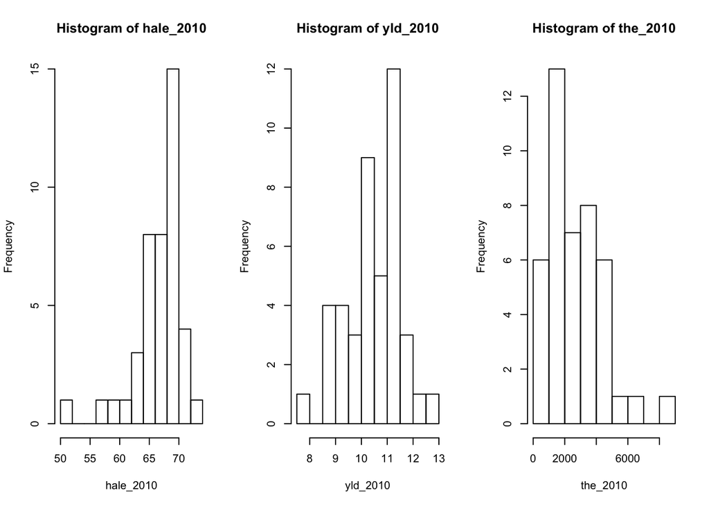

```r
# Histograms
par(mfrow=(c(1,3)))
hist(hale_2010, breaks=10)
hist(yld_2010, breaks=10)
hist(the_2010, breaks=10)
```

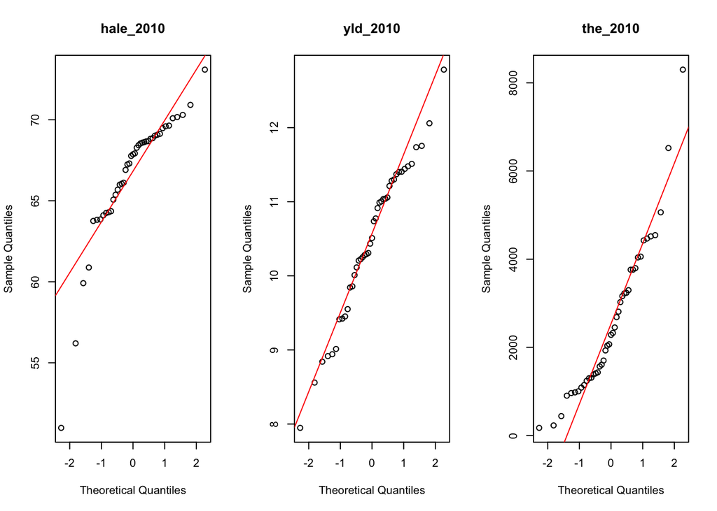

```r
# Normality and skewness
par(mfrow=(c(1,3)))
qqnorm(hale_2010, main="hale_2010")
qqline(hale_2010, col="red")
qqnorm(yld_2010, main="yld_2010")
qqline(yld_2010, col="red")
qqnorm(the_2010, main="the_2010")
qqline(the_2010, col="red")
```

### Model, Multiple Linear Regression and Robustness

```r
# Linear regression
model <- lm(log(the_2010)~yld_2010 + hale_2010)

summary(model)
```

```
##
## Call:
## lm(formula = log(the_2010) ~ yld_2010 + hale_2010)
##
## Residuals:
##      Min       1Q   Median       3Q      Max
## -1.03921 -0.20013 -0.01512  0.23092  1.36281
##
## Coefficients:
##             Estimate Std. Error t value Pr(>|t|)
## (Intercept) -2.29363    1.26525  -1.813 0.077375 .
## yld_2010     0.38014    0.08382   4.535 5.13e-05 ***
## hale_2010    0.08886    0.02189   4.059 0.000223 ***
## ---
## Signif. codes:  0 '***' 0.001 '**' 0.01 '*' 0.05 '.' 0.1 ' ' 1
##
## Residual standard error: 0.4871 on 40 degrees of freedom
## Multiple R-squared:  0.6528, Adjusted R-squared:  0.6354
## F-statistic:  37.6 on 2 and 40 DF,  p-value: 6.496e-10
```

```r
coef(model)
```

```
## (Intercept)    yld_2010   hale_2010
## -2.29362738  0.38014245  0.08886168
```

```r
exp(coef(model)["yld_2010"])
```

```
## yld_2010
## 1.462493
```

```r
exp(coef(model)["hale_2010"])
```

```
## hale_2010
##  1.092929
```

```r
confint(model)
```

```
##                   2.5 %    97.5 %
## (Intercept) -4.85080002 0.2635453
## yld_2010     0.21074454 0.5495404
## hale_2010    0.04461478 0.1331086
```

```r
exp(confint(model))
```

```
##                   2.5 %   97.5 %
## (Intercept) 0.007822117 1.301536
## yld_2010    1.234596920 1.732457
## hale_2010   1.045624989 1.142374
```

```r
# VIF
vif(model)
```

```
##  yld_2010 hale_2010
##  1.348474  1.348474
```

```r
# General Linear Hypothesis Test
library("multcomp")
interact <- glht(model)
interact
```

```
##
##   General Linear Hypotheses
##
## Linear Hypotheses:
##                  Estimate
## (Intercept) == 0 -2.29363
## yld_2010 == 0     0.38014
## hale_2010 == 0    0.08886
```

```r
summary(interact)
```

```
##
##   Simultaneous Tests for General Linear Hypotheses
##
## Fit: lm(formula = log(the_2010) ~ yld_2010 + hale_2010)
##
## Linear Hypotheses:
##                  Estimate Std. Error t value Pr(>|t|)
## (Intercept) == 0 -2.29363    1.26525  -1.813    0.171
## yld_2010 == 0     0.38014    0.08382   4.535   <0.001 ***
## hale_2010 == 0    0.08886    0.02189   4.059   <0.001 ***
## ---
## Signif. codes:  0 '***' 0.001 '**' 0.01 '*' 0.05 '.' 0.1 ' ' 1
## (Adjusted p values reported -- single-step method)
```

```r
# Analysis of Variance Table
anova(model)
```

```
## Analysis of Variance Table
##
## Response: log(the_2010)
##           Df  Sum Sq Mean Sq F value    Pr(>F)
## yld_2010   1 13.9302 13.9302  58.719 2.277e-09 ***
## hale_2010  1  3.9085  3.9085  16.475 0.0002226 ***
## Residuals 40  9.4894  0.2372
## ---
## Signif. codes:  0 '***' 0.001 '**' 0.01 '*' 0.05 '.' 0.1 ' ' 1
```

```r
# Prediction
predconf <- predict(model, data.frame(yld_2010 = median(tidy.data$yld_2010), hale_2010 = median(tidy.data$hale_2010)), interval="confidence")
predconf
```

```
##        fit      lwr      upr
## 1 7.732801 7.573285 7.892317
```

```r
lower <- exp(predconf[,"lwr"])
fit <- exp(predconf[,"fit"])
upper <- exp(predconf[,"upr"])
mat <- cbind(fit, lower, upper)
df <- data.frame(mat)
df
```

```
##        fit    lower    upper
## 1 2281.985 1945.521 2676.639
```

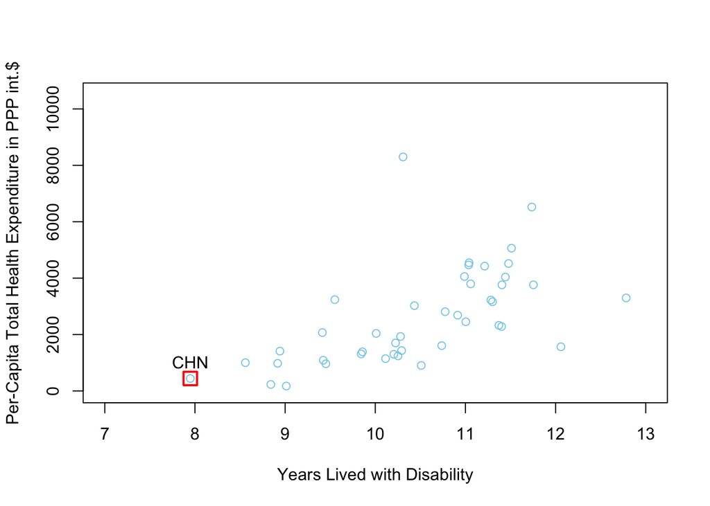

```r
# Summarise the relationship between THE and YLD
par(mfrow=(c(1,1)))
plot(yld_2010, the_2010,
     xlim = c(7, 13),
     ylim = c(0, 10500),
     xlab="Years Lived with Disability",
     ylab="Per-Capita Total Health Expenditure in PPP int.$",
     col="skyblue")

points(tidy.data$yld_2010[tidy.data$country == ID], tidy.data$the_2010[tidy.data$country == ID], pch=22, col="red", cex = 2, lty = "solid", lwd = 2)

text(tidy.data$yld_2010[tidy.data$country == ID], tidy.data$the_2010[tidy.data$country == ID], labels=ID, cex= 1, pos=3)
```